# Multiple Linear Regression Report

Determining water quality metrics linear regression

Author

eamonn

```r
# adding reference to source file which contains functions we will use in this qmd file
source("MATH9102-W9-Functions.R")

#| label: install-and-load
#| message: false
#| warning: false

quiet_library <- function(pkg) {
  suppressMessages(suppressWarnings({
    if (!requireNamespace(pkg, quietly = TRUE)) {
      install.packages(pkg, quiet = TRUE)
    }
    library(pkg, character.only = TRUE)
  }))
}


quiet_library("tidyverse")  # Collection of R packages (dplyr, ggplot2, tidyr, etc.) for data wrangling, visualization, and analysis
quiet_library("lm.beta")   # For extracting standardized co-efficients from regression model
quiet_library("stargazer") # For formatting output of regression
quiet_library("performance")    # Loads tools for checking model assumptions and diagnostics (e.g., normality, collinearity)
quiet_library("car")            # Companion to Applied Regression – includes functions for influence tests and outlier detection
quiet_library("see")            # Needed for plots
quiet_library("ggResidpanel")   # Alternative for generating diagnostic plots for 4.5.x
quiet_library("stats")   # Core R statistical functions (cor.test, oneway.test, bartlett.test)
quiet_library("rstatix")   # User-friendly statistical tests (Tukey HSD post-hoc)
quiet_library("effectsize")   # Computes and interprets effect sizes (e.g., eta squared, Cohen’s d)
quiet_library("psych")  # Descriptive statistics for grouped data (describeBy)
quiet_library("ggplot2")   # Data visualization (histograms, QQ plots, diagnostic plots)
quiet_library("VIM")   # Visualization of missing data patterns (aggr)
quiet_library("kableExtra")   # Enhances tables created with knitr::kable (styling, layout)
quiet_library("knitr")   # Generates formatted tables and report outputs (kable)


# Code to load file
datalocation <- file.path("./")
datapath <- file.path(datalocation,"WQI Results on Dataset.csv")

#Read in the csv file dataset
wqi_df <- read.csv(datapath, header=TRUE)
#Setting the column names to be that used in the dataset but in lowercase to make life a bit easier
colnames(wqi_df) <- tolower(colnames(wqi_df))


# Complete any manipulation/cleaning needed
```

```r
#
# Define variables that we want to use in or analysis
# we'll craete a subset of the data with just those to keep our dataset as light as we can.
varsint <- c("waterbodyname",  "years",  "sampledate",  "alkalinity.total..as.caco3.",  "bod...5.days..total.", "ammonia.total..as.n.", "chloride", "conductivity..25.c",  "dissolved.oxygen",  "ph",  "temperature",  "total.hardness..as.caco3.", "true.colour", "ccme_wqi",  "wawqi",  "horton.wqi",  "brown.wqi",  "srdd.wqi")

# create data subset of variables we want to lok at
wqi_dsubset <- wqi_df[varsint]


#  human friendly labels
colnames(wqi_dsubset) <- c( "waterbodyname", "years", "month", "alkalinity",  "biochem_ox_dmnd", "ammonia", "chloride", "conductivity", "dissolved.oxygen", "ph",  "temperature", "hardness", "colour", "ccme_wqi",  "wawqi",  "horton.wqi",  "brown.wqi",  "srdd.wqi")
```

# 1. Introdction

This analysis uses water quality data which was taken over a period of 16 years from 2007 to 2023 across 16 locations in Ireland by the Environmental Protection Agency(EPA). The data was then used to classify water quality at these locations. The data set was sourced from the following location [Water Quality Monitoring Dataset (Ireland)](https://figshare.com/articles/dataset/Water_Quality_Monitoring_Dataset_Ireland_/25002131), and is a merging of multiple csv files from the EPA into a single source.

Water samples were taken from 160 sites within these 16 geographical areas, at various times throughout the year, tested in labs, and calculations were then carried out to determine Water Quality according to different water quality standards, a number of which exist.

## 1.1 Purpose of Analysis

The analysis will consist of two parts

## 1.2 MLR Overview (assignment task 1)

The purpose of this part analysis is to investigate the extent to which key water quality measurements can explain variation in the **biochemical oxygen demand (BOD)** variable, which is a widely used metric to indicate water quality and will be used as our **outcome** variable. - High ‘BOD’ values indicating increased oxygen consumption by microbes breaking down organic material in the water, and thus less oxygen being available for living organisms in the water such as fish and aquatic plants, meaning lower water quality. It can be seen as a measure of microbe activity, the higher the BOD value the more microbe activity. - Lower values of ‘BOD’, indicating more oxygen being available in the water, providing a higher level of water quality.

For *predictor variables* in (assignment phase two task 1), we will use the following continuous integer or ratio variables: - **dissolved oxygen (DO)**: a key water quality measurable providing the amount of oxygen present in water. We expect to see the more dissolved oxygen present, the better the water quality, thus the lower the BOD value. - **temperature**: influences how soluble substances are within water, including oxygen and organic matter. This should affect BOD value at the extremes higher and lower. - **ph**: acidity / alkaline indicator which affects support for various processes, both chemical and organic. Similar to temperature we expect to see poorer water quality at extreme values of **ph**.

A **differential (interaction) effect* will be included in our MLR model. The impact of temperature on the BOD value will depend on the amount of DO present in the water. - At low DO, increased temperature will increase the microbe activity, i.e. resulting in a higher BOD value, - At High DO, the temperature effect will less of an impact on BOD

## 1.3 MLR Comparison Overview (assignment task 3)

The purpose of this comparison model analysis is to determine if the relationship between the outcome variable, **biochemical oxygen demand (BOD)**, and the predictor variables, **dissolved oxygen**,**temperature** and **ph**, changes per month. This will be achieved by adding a predictor variable, a categorical predictor. **month**, which is the month in which the data was taken. Month will be treated as a ‘nominal’ variable, with *Jan* used as the reference category and dummy variables used or the remaining months, allowing us to determine the differential effects in relation to that month throughout the year.

## 1.4 MLR - Hypothesis- (assignment task 1)

- H1: **dissolved oxygen**,**temperature** and **ph** significantly predict **biochemical oxygen demand (BOD)** and the effect of **temperature** on **BOD** is significantly moderated by the interaction effect between temperature and DO, present in the water.

## 1.5 MLR Comparison - Hypothesis - (assignment task 3)

H2 - Including **month** as a categorical predictor significantly improves the model, effectively explaining **BOD** monthly variations, relative to January.

Throughout the analysis, a significance threshold of 0.05 was used, and effect sizes were reported according to Cohen’s conventions(1988).

# 2. Data Description and Preparatinon

## 2.1 Overview

The dataset contains ‘29,159’ rows and ‘18’ variables typically included in water quality analysis such as **ph**, **temperature**, **biochemical oxygen demand *BOD**,** dissolved oxygen**,** alkalinity** and others. The concepts of interest, their measurement and statistical type are shown in Tables 1 and 2 below.

| variable | r_type | is_factor | factor_summary |
| --- | --- | --- | --- |
| waterbodyname | factor | TRUE | 160 levels (e.g., ABBEYTOWN_010, Allua,) |
| years | integer | FALSE | NA |
| month | factor | TRUE | 12 levels (e.g., Jan, Feb, …) |
| alkalinity | double | FALSE | NA |
| biochem_ox_dmnd | double | FALSE | NA |
| ammonia | double | FALSE | NA |
| chloride | double | FALSE | NA |
| conductivity | double | FALSE | NA |
| dissolved.oxygen | double | FALSE | NA |
| ph | double | FALSE | NA |
| temperature | double | FALSE | NA |
| hardness | double | FALSE | NA |
| colour | double | FALSE | NA |
| ccme_wqi | factor | TRUE | 5 levels (e.g., Excellent, Fair, …) |
| wawqi | factor | TRUE | 6 levels (e.g., Excellent, Fair, …) |
| horton.wqi | factor | TRUE | 6 levels (e.g., Excellent, Fair, …) |
| brown.wqi | factor | TRUE | 5 levels (e.g., Excellent, Fair, …) |
| srdd.wqi | factor | TRUE | 6 levels (e.g., Excellent, Fair, …) |

Table 1. Variable and Statistical Datatypes present in the data set

Note the presence of several WQI categorical variables.These are water quality metrics form difference classification standards, of which there are a few. We will not use these as part of our multiple linear regression model.

We will create a reduced dataset to include primarily just the variables required for our two models, namely, **month**, **dissolved.oxygen**, **ph** and **temperature**.

[output not shown]

Table 2. Continuous (Interval/Ratio) Data Descriptions

Detailed analysis of our data was performed in the previous assignment phase 1, and is available for viewing there. We will not include all of that here. Rather we will include some of the most relevant points, and any additional analysis where it is felt it is required.

**Some General observations:**

- **Biochemical Oxygen Demand (BOD, mg/L)** - very stable data, 75% of data below 1.2 value, there is a potential outlier present though.
- **ph** - mean values
- **Temperature (°C)** - range from just above freezing and 3rd quantile approx 13 C. There is an outlier here.

There do appear to be some outliers, particularly in temperature, with a temperature of 637 C not be a real value. This may be due to a broken thermometer, or perhaps data entry error. Conductivity, has a 3rd quantile value of 501 yet has a max value of 42000. This could be an outlier however we need to determine if extreme values are outliers or actual real data due to extreme environmental conditions

Visual inspection of the histograms and Q–Q plots for all predictor and outcome variables were preformed in assignment 1. The standardized scores for skewness and kurtosis, as well as the percentages of absolute z-scores exceeding ±3.29, were inspected.

## 2.2 Outcome variable overview

we will look a little closer at the BOD values hre as our outcome variable.

```r
wqi_dsubset4 <- wqi_dsubset

# use pastec stats describe to get basic statistics
pastecs::stat.desc(wqi_dsubset4$biochem_ox_dmnd, basic = FALSE)
```

```
      median         mean      SE.mean CI.mean.0.95          var      std.dev
 1.200000000  1.276860523  0.003278813  0.006426623  0.313477251  0.559890392
    coef.var
 0.438489860
```

```r
# will give us mean, sd, median, skew, kurtosis, etc.
psych::describe(wqi_dsubset4$biochem_ox_dmnd)
```

```
   vars     n mean   sd median trimmed mad min max range skew kurtosis se
X1    1 29159 1.28 0.56    1.2     1.2   0   0  16    16  8.1   119.42  0
```

```r
# Standardized scores for skewness and kurtosis
bod_skew <- semTools::skew(wqi_dsubset4$biochem_ox_dmnd)
bod_kurt <- semTools::kurtosis(wqi_dsubset4$biochem_ox_dmnd)
bod_skew_z <- bod_skew[1] / bod_skew[2]
bod_kurt_z <- bod_kurt[1] / bod_kurt[2]

# print otu the standadized skew and kurtosis
cat("Standardised skewness (z):", round(bod_skew_z, 2), "\n")
```

```
Standardised skewness (z): 564.92
```

```r
cat("Standardised kurtosis (z):", round(bod_kurt_z, 2), "\n")
```

```
Standardised kurtosis (z): 4163.71
```

```r
#Calculate percentage of standardized scores for bod
# are within our limits of +/- 1.96, +/- 3.29
zbod <- abs(scale(wqi_dsubset4$biochem_ox_dmnd))

# % beyond ±1.96 (approx 5% expected in normal data)
FSA::perc(as.numeric(zbod), 1.96, "gt")
```

```
[1] 3.131109
```

```r
# % beyond ±3.29 (approx 0.1% expected in normal data)
FSA::perc(as.numeric(zbod), 3.29, "gt")
```

```
[1] 1.351212
```

```r
# Calculate the # of unique values for BOD prior to cleaningand the values

wqi_dsubset_2 <- wqi_dsubset
names(wqi_dsubset_2)
```

```
 [1] "waterbodyname"    "years"            "month"            "alkalinity"
 [5] "biochem_ox_dmnd"  "ammonia"          "chloride"         "conductivity"
 [9] "dissolved.oxygen" "ph"               "temperature"      "hardness"
[13] "colour"           "ccme_wqi"         "wawqi"            "horton.wqi"
[17] "brown.wqi"        "srdd.wqi"
```

```r
# This calculates counts and percentages in one go
result <- wqi_dsubset_2 %>%
  # get count
  count(biochem_ox_dmnd) %>%
  # get percentage
  mutate(Percentage = (n / sum(n)) * 100) %>%
  # rename cols
  rename(Value = 1, Count = 2) %>%
  # sort descending
  arrange(desc(Count))

head(result, 5)
```

```
  Value Count Percentage
1   1.2 20553  70.485956
2   1.0  1439   4.935011
3   1.1  1008   3.456909
4   1.3   718   2.462362
5   1.4   560   1.920505
```

Data inspection of the Biochemical Oxygen Demand (BOD) here, and visual inspection in assignment 1, showed the following, histogram indicated a highly positive skew with standardised skewness (z = 564.87) with pronounced leptokurtosis with standardised kurtosis (z = 4163.14). The Q–Q plot indicated a strong right tail, showing a small number of high BOD readings (up to 16) among predominantly low values (mean = 1.27 and median = 1.20 and a standard deviation = 0.55). Also, greater than 70% of the values were a single value of 1.2 mg/L.

To address the skewness and non-normal distribution, we will apply a transform to the log10.

Also, **month** variable values are listed as categorical ordinal in the earlier table, we will treat month as nominal categorical data in or model. This will allow us do comparison of monthly differences without have an implied linear relationship. We have sufficient data per month to allow us include as a categorical predictor.

## 2.3 Water Quality metrics

The following are some facetted plots of variables of interest for a quality standard. We are using the water quality measurement of **CCME WQI**, an its categories *Excellent* and *Poor** and the corresponding variable values that correspond to these. This is performed just to give us an insight into how the variables translate into water quality, based of an already defined international classification method.

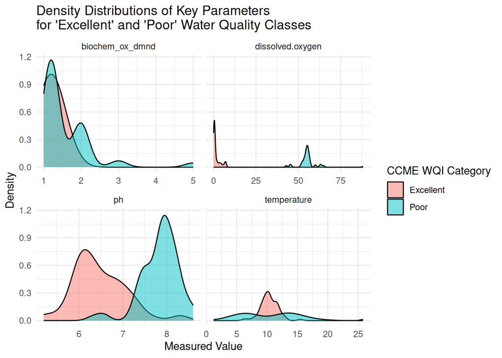

Water Quality variance per variable

```r
# create  facetted plot of excellent and poor for our data types t
# pipe the data into long format fo plotting specifyign what variables to sue
# and store in wqi_long dataframe
mlr_t1_t3_df_wq <- wqi_dsubset
wqi_long <- mlr_t1_t3_df_wq%>%
  tidyr::pivot_longer(
    cols = c(ph, temperature, biochem_ox_dmnd, dissolved.oxygen),
    names_to = "parameter",
    values_to = "value"
  )

# keep onyl quality rows that contain v aleu of interest
mlr_t1_t3_df_wq <- wqi_long %>% filter(ccme_wqi %in% c("Excellent", "Poor"))

# create the facetted plot, set transparency to 0.5
ggplot(mlr_t1_t3_df_wq, aes(x = value, fill = ccme_wqi)) +
  geom_density(alpha = 0.5) +
  facet_wrap(~ parameter, scales = "free_x", ncol = 2) +
  theme_minimal() +
  labs(
    title = "Density Distributions of Key Parameters\nfor 'Excellent' and 'Poor' Water Quality Classes",
    x = "Measured Value",
    y = "Density",
    fill = "CCME WQI Category"
  )
```

The density plots highlight differences in distribution shape between water quality classes according to the **CCME WQI** classification# standards.

- **bod**: Excellent Water Quality is achieved between 1-2.5 mg/L, not above this, but poor water quality can occur at any range of values. This explains our high percentage of BOD values at 1.2 mg/L.
- **dissolved oxygen**: Excellent water quality is achieved at lower values while poor water quality is achieved at higher values circa 50+. This pattern is contrary to the expected ecological relationship between DO and water quality, where higher oxygen typically indicates better conditions. The reversal may reflect dataset-specific factors such as differences between coastal or marine sampling locations, possible sensor calibration differences, or the weighting of dissolved oxygen within the CCME WQI calculation. This variable has also been classified as multimodal earlier. This would require further investigation.
- **ph**: We see that the higher the ph value the poorer the water quality.
- **temperature**: There is a sweet spot between approx 9 and 12 where excellent quality occurs. Values higher (between approx 13C-18C) or lower (between approx 0C and 7C) lead to poorer water quality

## 2.3 Clean and Prepare the Data

```r
# Temperature variable -  delete these rows
wqi_dsubset_clean_t <- wqi_dsubset %>% filter(temperature <= 40 | is.na(temperature))

# Biochemical Oxygen Demand (BOD) variable -  transform to the 'log10' to address
wqi_dsubset_clean_t_bod <- wqi_dsubset_clean_t %>%
  # add +1 to handle zeros safely and rename the variables
  mutate(bod_log10 = log10(biochem_ox_dmnd + 1))
```

```r
mlr_t1_t3_df <- wqi_dsubset_clean_t_bod %>% select(month, bod_log10, dissolved.oxygen, temperature, ph)

summary(mlr_t1_t3_df)
```

```
    month             bod_log10      dissolved.oxygen  temperature
 Length:29154       Min.   :0.0000   Min.   :  0.00   Min.   : 0.60
 Class :character   1st Qu.:0.3424   1st Qu.: 49.40   1st Qu.: 8.20
 Mode  :character   Median :0.3424   Median : 54.90   Median :10.70
                    Mean   :0.3497   Mean   : 58.29   Mean   :10.82
                    3rd Qu.:0.3424   3rd Qu.: 75.00   3rd Qu.:13.10
                    Max.   :1.2304   Max.   :198.00   Max.   :27.40
       ph
 Min.   :4.700
 1st Qu.:7.200
 Median :7.700
 Mean   :7.552
 3rd Qu.:8.000
 Max.   :9.800
```

```r
# Calculate the # of unique values for BOD after to cleaning and the values
mlr_t1_t3_df_2 <- mlr_t1_t3_df
# Get counts for each unique value
counts <- table(mlr_t1_t3_df_2$bod_log10)

# top 10 most frequent values
sort(counts, decreasing = TRUE) |> head(10)
```

```
0.342422680822206 0.301029995663981 0.322219294733919 0.361727836017593
            20551              1439              1008               718
0.380211241711606 0.397940008672038 0.414973347970818 0.477121254719662
              560               406               328               312
0.431363764158987 0.230448921378274
              288               255
```

```r
# carete a frequency table
freq_table <- table(mlr_t1_t3_df_2$bod_log10)
# convert to percentages
perc_table <- prop.table(freq_table) * 100
# put into dataframe and sort
result <- as.data.frame(perc_table)
colnames(result) <- c("Value", "Percentage")
result <- result[order(-result$Percentage), ]

head(result, 5)
```

```
                Value Percentage
87  0.342422680822206  70.491185
68  0.301029995663981   4.935858
78  0.322219294733919   3.457502
96  0.361727836017593   2.462784
105 0.380211241711606   1.920834
```

Our final working dataset contains ‘29,154’ rows and ‘5’ variables

As per the assignment phase 1 analysis, the following steps were applied to create our working data set for this task along with any additional considerations mentioned below.

- **BOD log10**
  - To address the skewness we applied a transform to the ‘log10’.
  - the BOD log 10 show a correction to the previous positive skewness in the histogram, and while there is still deviation from the tails we now have Standardised skewness (z = 184.15) and standardised kurtosis (z = 676.68). However, aproximately 93.6% of standardized scores lay within ±1.96 , and 97,96% are within ±3.29 z, (Curran, West, & Finch, 1996). Following the guidance of Field, Miles, and Field (2012), the data can be considered to approximate a normal distribution.
  - The transofrmed data still contains a large number of values which are for a single value i.e. > 70% of values are a single value of 0.3424
- **Temperature**
  - removed any temp value above 40 degrees, to ensure we have realistic temp values and remove outliers.
- **Dissolved Oxygen**
  - Analysis showed the DO data to be non normal, rather it is multi-modal.
  - A multi-modal distribution of values is oresent with the QQ plot shows minor deviations from normal at the tails, and somewhat through the centre. Standardized skewness (z = -1.88) and kurtosis (z = -4.66) were not statistically significant, and only 93% of standardized scores exceeded ±1.96 and 99.9% exceeded ±3.29, using the criteria proposed by Curran, West and Finch (1996). Using visual plot data and the guidance of Field, Miles and Field (2012), the data can be considered to bimodal or potentially multimodal
  - We will not apply a transformation to this variable data, rather consider it non-parametric.
  - As predictor variables are not required to be normally distributed in linear regression, we leave this in its original state for this variable.
- **ph**
  - No Changes made
- **month**
  - no changes made

## 2.4 Exploratory Data Analysis

Exploratory data analysis was carried out to seek evidence supporting and to help shape and validate decisions for predictor ad outcome variables prior to the building of the model. This is based solely on our data subset, not the wider dataset.

## 2.5 Missing Data

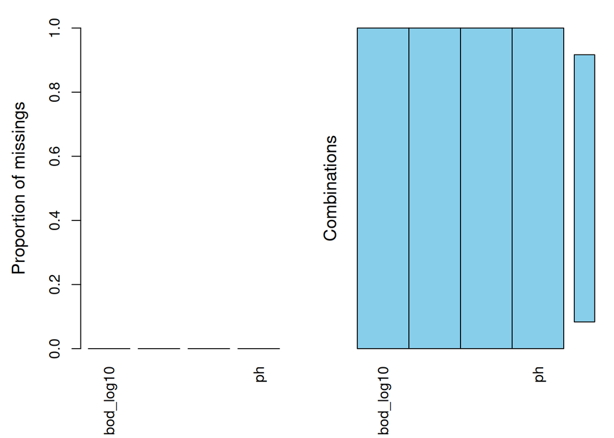

```
 Variables sorted by number of missings:
         Variable Count
        bod_log10     0
 dissolved.oxygen     0
      temperature     0
               ph     0
```

```r
# Prepare data for missingness check
#| fig-cap: "Missing Data for outcome and predictor variables "
mdata <- mlr_t1_t3_df %>% select(bod_log10, dissolved.oxygen, temperature, ph) %>% as.data.frame()

# Reset row names (this fixes the error)
row.names(mdata) <- NULL

# Missing data inspection
VIM::aggr(mdata,sortVar = TRUE, combined = FALSE)
```

There is no missing data present in our dataset.

## 2.6 Visualizations of variables

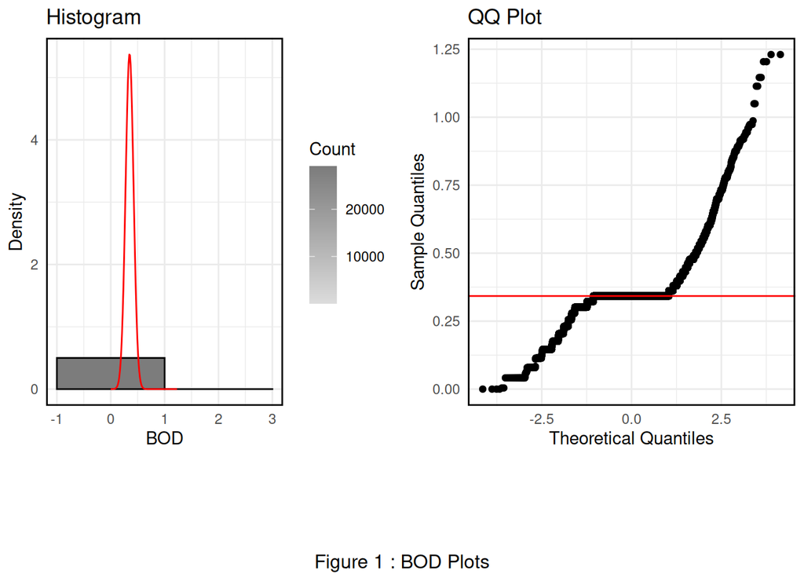

Distribution plots for outcome and predictor variables

```r
# Generate plots using function plot_ratio_variable
plot_ratio_variable(mlr_t1_t3_df, "bod_log10", "BOD", 1)
```

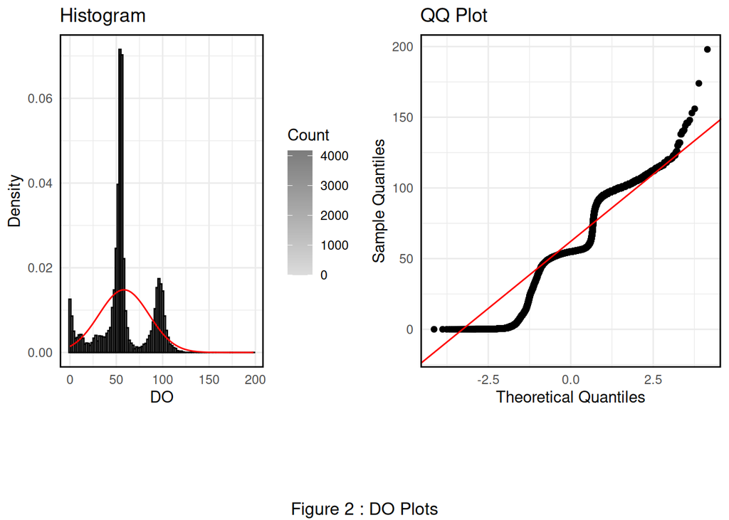

Distribution plots for outcome and predictor variables

```r
plot_ratio_variable(mlr_t1_t3_df, "dissolved.oxygen","DO",2)
```

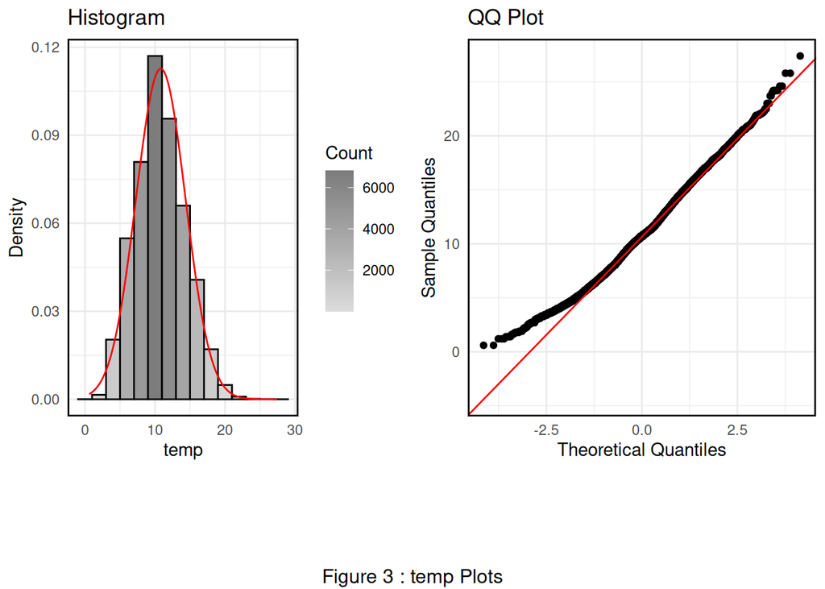

Distribution plots for outcome and predictor variables

```r
plot_ratio_variable(mlr_t1_t3_df, "temperature", "temp", 3)
```

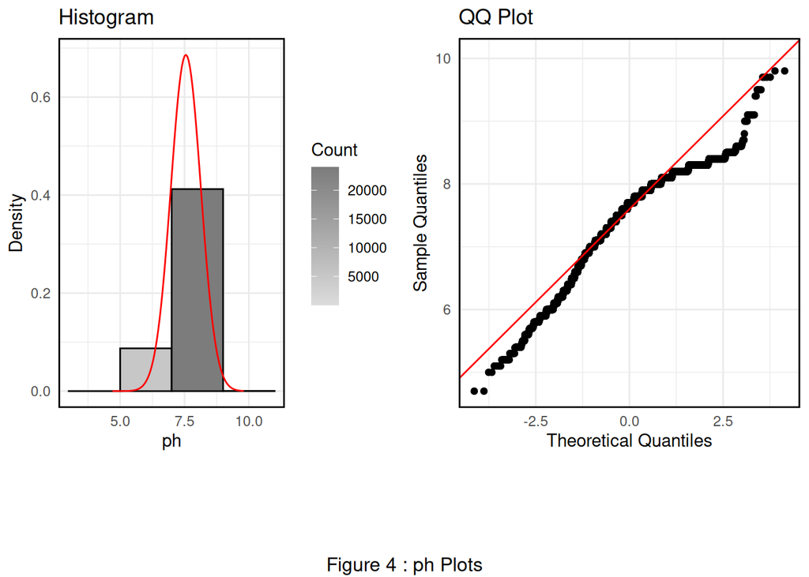

Distribution plots for outcome and predictor variables

```r
plot_ratio_variable(mlr_t1_t3_df, "ph", "ph", 4)
```

The above historgam and QQ plots of our variables provide evidence supporting our decisions to transform **BOD** to Log10, to address positive skewness and non normality. We can visually see the presence of multi modal distribution in **DO** data. No transformation was applied as is not required to fit to linear regression model, and we retain our ability to interpret the data more easily. The**Temp** data being our most evenly distributed and closest to normality, after havign removed some outliers. And finally, our ph values havign a near normal distribution

The QQ plot for BOD also shows a horizontal plateau region in the data, this could be an expected effect de to environmental factors, or also potentially due to a testing practice or methodology and could be a limiting factor

As ws assessed in the previous assignment, using the guidance of Field, Miles and Field (2012), if 98% of the data fell between +/- 3.29 the distribution was considered to be approximately normal, and Skewness and Kurtosis values between –2 and +2 ≈ were acceptable

## 2.7 Colineaity of variables

The relationships between the concepts of interest were investigated before linear regression models were constructed to ensure that a linear relationship could be considered to exist between the proposed dependent variable and proposed predictors.

```r
r1=stats::cor.test(mlr_t1_t3_df$dissolved.oxygen, mlr_t1_t3_df$bod_log10)
r2=stats::cor.test(mlr_t1_t3_df$temperature, mlr_t1_t3_df$bod_log10)
r3=stats::cor.test(mlr_t1_t3_df$ph, mlr_t1_t3_df$bod_log10)
```

Pearson correlations were conducted to asses the level of relationship between **BOD** and each of the predictor variables, **dissolved.oxygen (DO)**, **temperature (Temp)**, and **ph**. There is a statistically significant, positive, weak correlation between **BOD** and **DO**. (p < 0.05, Corr.Co-eff(r) = 0.02, ). There is a statistically significant, positive, weak correlation between **BOD** and **Temp**. (p < 0.05, Corr.Co-eff(r) = 0.1, ). There is a statistically significant, positive, very weak correlation between **BOD** and **ph**. (p < 0.05, Corr.Co-eff(r) = 0.07, ).

```r
#| tbl-cap: "Correlations between BOD and Precictor Variables"

# Create a data frame for the correlation results

corr_table <- data.frame(
Dependent = c("bod_log10", "bod_log10", "bod_log10"),
Predictor = c("dissolved.oxygen", "temperature", "ph"),
`Correlation Coefficient (r)` = c(
round(r1$estimate, 2),
round(r2$estimate, 2),
round(r3$estimate, 2)
),
Significance = c("p < 0.001", "p < 0.001", "p < 0.001")
)

knitr::kable(
corr_table)
```

| Dependent | Predictor | Correlation.Coefficient..r. | Significance |
| --- | --- | --- | --- |
| bod_log10 | dissolved.oxygen | 0.02 | p < 0.001 |
| bod_log10 | temperature | 0.10 | p < 0.001 |
| bod_log10 | ph | 0.07 | p < 0.001 |

## 2.8 Linearity between outcome and predictors

Scatterplots of the outcome variable and predictor variables demonstrate linear trends for each of the predictor variables, again supporting their use in our model creation.

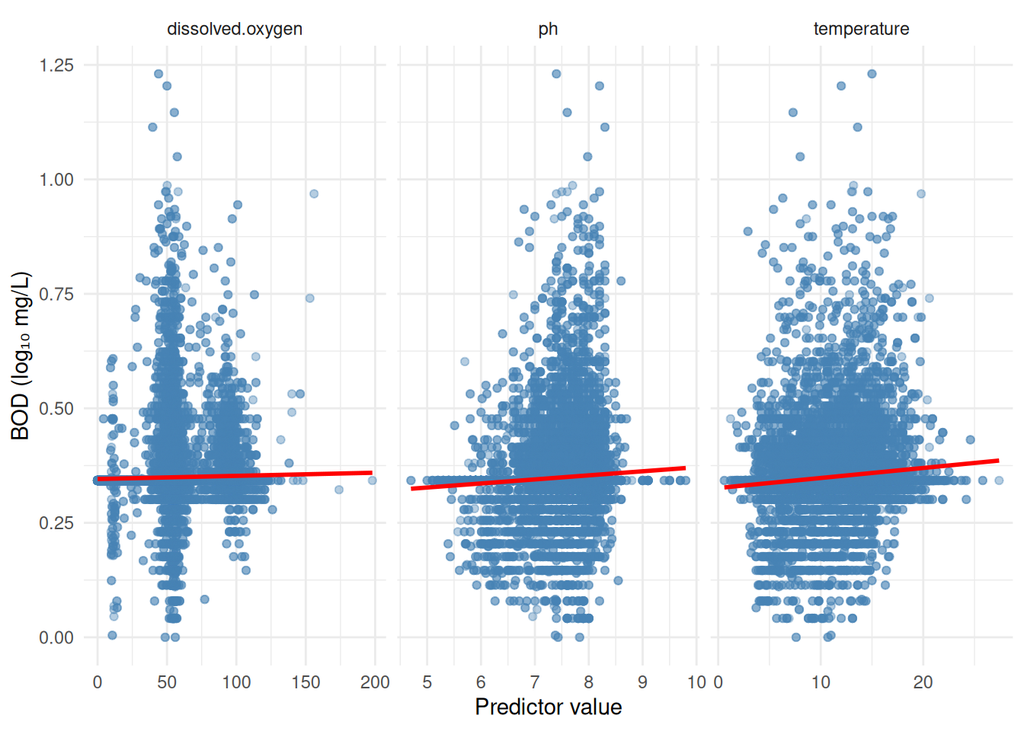

Linearity of outcome and predictor variables

```r
mlr_long <- mlr_t1_t3_df %>%
  select(bod_log10, dissolved.oxygen, temperature, ph) %>%
  pivot_longer(cols = -bod_log10, names_to = "predictor", values_to = "value")

ggplot(mlr_long, aes(x = value, y = bod_log10)) +
  geom_point(alpha = 0.4, colour = "steelblue") +
  geom_smooth(method = "lm", colour = "red", se = FALSE) +
  facet_wrap(~ predictor, scales = "free_x") +
  labs(x = "Predictor value", y = "BOD (log₁₀ mg/L)") +
  theme_minimal()
```

## 2.9 Homogeneity of variance check

A Bartlettes test of homogeneity of variances was carried out on the categorical variable we are considering using as a predictor, i.e. **month** against **BOD**, our outcome variable. The test returned values of (K^2 = 1038, df=11, p-value < 2.2e-16. The effect size is quite small at Eta squared = 8.08*10^-3 (i.e. approx = 0.008), meaning while it is statistically significant (p < 0.05) it only explains < 1% of the total **BOD** variance.

```r
#Get descriptive statistics by group - output as a matrix
# bOd by nonth
monthdesc<-psych::describeBy(mlr_t1_t3_df$bod_log10, group=mlr_t1_t3_df$month, mat=TRUE)

#Conduct Bartlett's test for homogeneity of variance
stats::bartlett.test(bod_log10 ~ month, data=mlr_t1_t3_df)
```

```
    Bartlett test of homogeneity of variances

data:  bod_log10 by month
Bartlett's K-squared = 1038, df = 11, p-value < 2.2e-16
```

```r
#Conduct ANOVA using the one-way ANOVA from the stats package
# we change var.equal to FALSE as environment data will typically have variances across month
# i.e. they will not be the same
res <- stats::oneway.test(bod_log10 ~ as.factor(month), data = mlr_t1_t3_df, var.equal = TRUE)

#We use Tukey for post-hoc testing
tukeyres <-rstatix::tukey_hsd(mlr_t1_t3_df, bod_log10 ~ month)

#Compute our effect size - Eta squared
# gives magntiude of the month effect on BOD
effes=effectsize::effectsize(res)
effes
```

```
Eta2     |       95% CI
-----------------------
8.06e-03 | [0.01, 1.00]

- One-sided CIs: upper bound fixed at [1.00].
```

```r
#Store the relevant pieces of the output from ANOVA in variables to use for reporting
#Degrees of freedom
df1=res$parameter[1]
df2=res$parameter[2]
#F statistic
Fstat=round(res$statistic, 3)
# Pvalue <- round(res$p.value)
pval=round(res$p.value,2)
eta2=round(effes$Eta2, 3)
```

# 3. Predicting BOD: The Impact of Dissolved Oxygen, Temperature, and pH.

This section discusses the multiple linear regression model developed to investigate the extent to which environment factors, specifically **dissolved oxygen**, **temperature** and **ph**, can be considered to predict water quality as indicated by **BOD**. The model’s fit and usefulness are examined, followed by a rigorous assessment of how it meets the assumptions of linear regression to ensure the reliability of the findings. Finally, the impact of each environmental measure on **BOD** and the model’s predictive power are evaluated, culminating in a discussion of the implications of these results.

## 3.1 Build the baseline model

```r
#Create the model 1 for task 1
# This is our baseline model
model1<-lm(bod_log10~dissolved.oxygen+temperature+ph+(temperature*dissolved.oxygen), data=mlr_t1_t3_df)
```

## 3.2 Generate Analysis of Variance Table

This provides the information needed to calculate the F statistic.

```r
anova(model1)
```

```
Analysis of Variance Table

Response: bod_log10
                                Df  Sum Sq Mean Sq F value    Pr(>F)
dissolved.oxygen                 1   0.100 0.09983  18.455 1.745e-05 ***
temperature                      1   1.773 1.77260 327.706 < 2.2e-16 ***
ph                               1   0.379 0.37934  70.129 < 2.2e-16 ***
dissolved.oxygen:temperature     1   0.240 0.23992  44.355 2.787e-11 ***
Residuals                    29149 157.670 0.00541
---
Signif. codes:  0 '***' 0.001 '**' 0.01 '*' 0.05 '.' 0.1 ' ' 1
```

## 3.3 Generate summary statistics needed to assess model fit

```r
summary(model1)
```

```
Call:
lm(formula = bod_log10 ~ dissolved.oxygen + temperature + ph +
    (temperature * dissolved.oxygen), data = mlr_t1_t3_df)

Residuals:
     Min       1Q   Median       3Q      Max
-0.34833 -0.01537 -0.00623  0.00171  0.87048

Coefficients:
                               Estimate Std. Error t value Pr(>|t|)
(Intercept)                   2.495e-01  6.956e-03  35.869  < 2e-16 ***
dissolved.oxygen              3.917e-04  6.045e-05   6.480 9.31e-11 ***
temperature                   4.320e-03  3.649e-04  11.841  < 2e-16 ***
ph                            6.979e-03  8.418e-04   8.291  < 2e-16 ***
dissolved.oxygen:temperature -3.520e-05  5.286e-06  -6.660 2.79e-11 ***
---
Signif. codes:  0 '***' 0.001 '**' 0.01 '*' 0.05 '.' 0.1 ' ' 1

Residual standard error: 0.07355 on 29149 degrees of freedom
Multiple R-squared:  0.01556,   Adjusted R-squared:  0.01542
F-statistic: 115.2 on 4 and 29149 DF,  p-value: < 2.2e-16
```

## 3.4 Generate Standardized Co-efficients

```r
lm.beta::lm.beta(model1)
```

```
Call:
lm(formula = bod_log10 ~ dissolved.oxygen + temperature + ph +
    (temperature * dissolved.oxygen), data = mlr_t1_t3_df)

Standardized Coefficients::
                 (Intercept)             dissolved.oxygen
                          NA                   0.14242364
                 temperature                           ph
                  0.20635229                   0.05473304
dissolved.oxygen:temperature
                 -0.17898976
```

## 3.5 Use Stargazer to produce a tidy output of ANOVA and Summary

```r
stargazer(model1, type="text") #Tidy output of all the required stats
```

```
========================================================
                                 Dependent variable:
                             ---------------------------
                                      bod_log10
--------------------------------------------------------
dissolved.oxygen                      0.0004***
                                      (0.0001)

temperature                           0.004***
                                      (0.0004)

ph                                    0.007***
                                       (0.001)

dissolved.oxygen:temperature         -0.00004***
                                      (0.00001)

Constant                              0.250***
                                       (0.007)

--------------------------------------------------------
Observations                           29,154
R2                                      0.016
Adjusted R2                             0.015
Residual Std. Error              0.074 (df = 29149)
F Statistic                  115.161*** (df = 4; 29149)
========================================================
Note:                        *p<0.1; **p<0.05; ***p<0.01
```

## 3.6 Report the results

A multiple linear regression model was created to investigate the extent to which environment factors, specifically **dissolved oxygen**, **temeprature** and **ph**, can be considered to predict water quality as indicated by **BOD**. A statistically significant regression equation was found (F(4, 29149) = 115.16, p < 0.001 with an adjusted R<sup>2</sup> of 0.015. The adjusted R squared value indicating that the variables only account for 1.5% of the variance in our **BOD** value however, and there must be other factors not in our dataset that are affecting the variance.

The regression equation is therefore:

BOD_log10 = 0.2495 + 0.0003917 * (DO) + 0.004320 * Temp + 0.006979 * ph - 0.00003520 * (DO x Temp)

This indicates the following:

- **Dissolved Oxygen** : Is a statistically significant positive predictor (Co-eff(b) = 0.00039, p < 0.001) of **BOD**. This indicates that, holding other variables constant, higher dissolved oxygen levels are associated with small increases in **BOD**. We saw earlier that excellent water quality is achieved at lower values of **DO** while poor water quality is achieved at higher values. This pattern is contrary to the expected ecological relationship between **DO** and water quality, where higher oxygen typically indicates better conditions. This may be explainable in this model by the use **DO** in the interaction effect, namely how it changes the impact of **temperature** on water quality, rather than being a simple linear predictor of quality. This would require further investigation, which unfortunately due to time constraints we cannot pursue at this stage.
- **temperature**: Is a statistically significant positive predictor (Co-eff(b) = 0.0043, p < 0.001) of **BOD**. This indicates that higher **temperature** results in higher **BOD** values which is an increase in microbial activity and reduced water quality. With a t-value = 11.84 as the highest t-value in our predictors, indicating this is our strongest predictor.
- **ph**: Is a statistically significant positive predictor (Co-eff(b) = 0.0069, p < 0.001) of **BOD**. However the standardised co-efficient indicates it is the weakest of the predictors.
- **dissolved oxygen x temperature (Interaction effect)**: The interaction between **DO** and **temperature** is statistically significant (Co-eff(b) = -0.000035, p < 0.001). As dissolved oxygen increases, the positive effect of temperature on **BOD** is moderated. With a t-value = -6.66, the absolute value indicates a strong effect,and the minus sign indicating a moderating effect. This is our second highest predictor.

NOTE: we do not know from the statistical output data which variable is acting as a moderator on which variable in our interaction effect i.e. **DO** moderating **temperature** or **temperature** moderating **DO**, as they are symmetrical mathematically. However it makes more logical and scientific sense for **DO** to act as a moderator on **temperature** than the other way around, hence we interpret it that way.

Our predictor ‘Pr(>|t|)’ values are all of the order of either ‘10^-16’ or ‘10^-11’ indicating the chances of the effects they apply to BOD being random chance is effectively zero, indicating they are all statistically significant.

The model results provides strong evidence of support for our **Hypothesis 1 (H1)**, namely that **dissolved oxygen**,**temperature** and **ph** significantly predict **biochemical oxygen demand (BOD)** and also the effect of **temperature** on **BOD** is significantly moderated by the interaction effect between **temperature** and **DO**. i.e.

- At low **DO**values , increases in **temperature** will result in *larger* increases in microbe activity, i.e. resulting in a higher **BOD** value.
- At higher **DO**, increases in **temperature** will result in *smaller* increases in **BOD** value.

Warmer water increases microbial activity, but when dissolved oxygen is more abundant in the water a change in temperature has less of an impact. When oxygen is scarce in water temperature has a greater impact on BOD.

Overall, while we conclude that our model is statistically significant it has relatively low predictive power, accounting for only 1.5 % of the BOD variance.

# 4. Residual Analysis

## 4.1 Generate Summary Statistics/Non-Zero Variance

```r
#Generate summary statistics
#If using   pastecs::stat.desc for continous variables - make sure you include the basic switch=F to ensure you don't get scienfitic notation

pastecs::stat.desc(mlr_t1_t3_df$bod_log10, basic = FALSE)
```

```
      median         mean      SE.mean CI.mean.0.95          var      std.dev
0.3424226808 0.3496854565 0.0004340990 0.0008508538 0.0054938374 0.0741204251
    coef.var
0.2119631334
```

```r
pastecs::stat.desc(mlr_t1_t3_df$dissolved.oxygen, basic = FALSE)
```

```
      median         mean      SE.mean CI.mean.0.95          var      std.dev
  54.9000000   58.2888228    0.1578220    0.3093383  726.1614193   26.9473824
    coef.var
   0.4623079
```

```r
pastecs::stat.desc(mlr_t1_t3_df$temperature, basic = FALSE)
```

```
      median         mean      SE.mean CI.mean.0.95          var      std.dev
 10.70000000  10.81885230   0.02073365   0.04063889  12.53284073   3.54017524
    coef.var
  0.32722281
```

```r
pastecs::stat.desc(mlr_t1_t3_df$ph, basic = FALSE)
```

```
      median         mean      SE.mean CI.mean.0.95          var      std.dev
 7.700000000  7.552068601  0.003404339  0.006672658  0.337880911  0.581275246
    coef.var
 0.076969010
```

## 4.2 Conduct a Normality Test

```r
# Check normality - conducts a Shapiro-Wilks test and checks the standardized residuals for normal distribution
# A p-value < 0.05 indicates a significant deviation from normal distribution.

performance::check_normality(model1)
#**Task:** Does the p-value suggest that residuals deviate significantly from normality? What does this mean for the model?
#or
#OK: residuals appear as normally distributed (p = 0.959).
```

[output not shown]

## 4.3 Visualize residual distribution

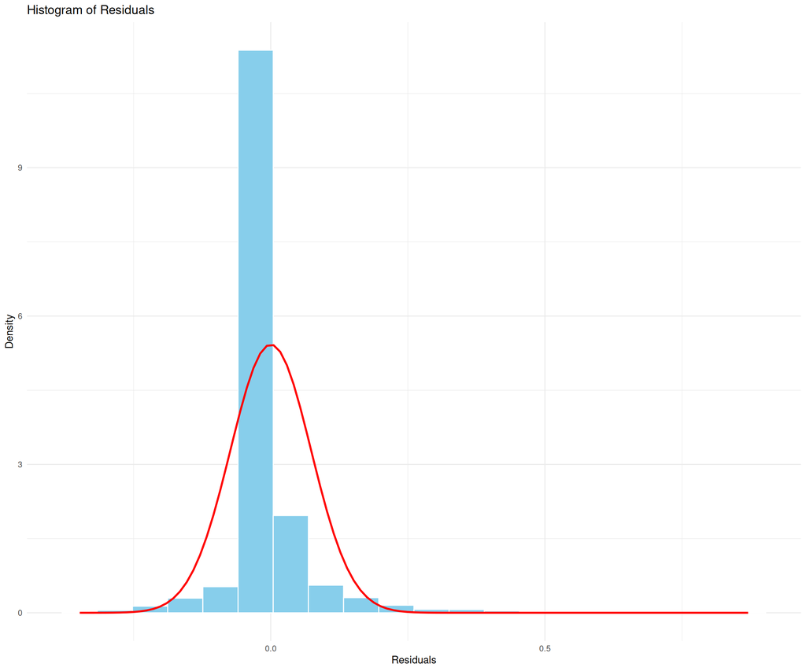

Residual Distribution Plots for Model 1

```r
# Visualize residual distribution


# Histogram of Residuals
ggplot(data.frame(residuals = resid(model1)), aes(x = residuals)) +
  geom_histogram(aes(y = ..density..),
                 bins = 20,
                 fill = "skyblue",
                 color = "white") +
  stat_function(fun = dnorm,
                args = list(mean = mean(resid(model1)), sd = sd(resid(model1))),
                color = "red",
                linewidth = 1) +
  labs(title = "Histogram of Residuals",
       x = "Residuals",
       y = "Density") +
  theme_minimal()
```

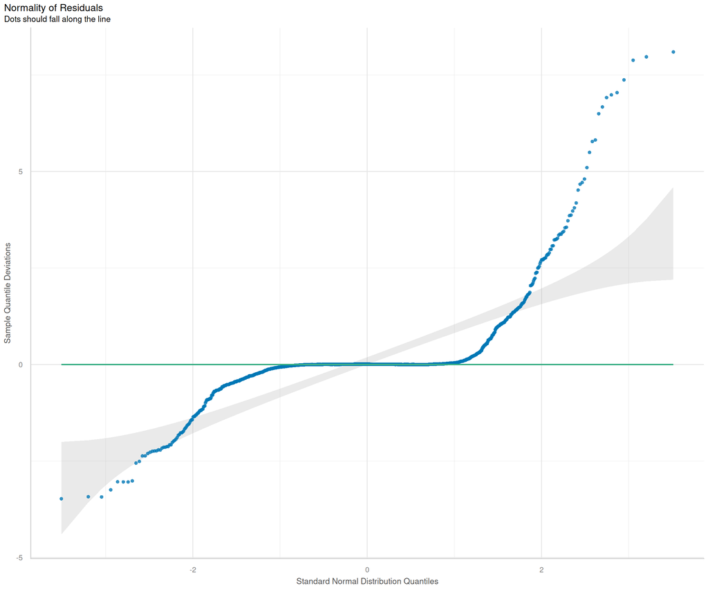

Residual Distribution Plots for Model 1

```r
# A transformed version of a Q–Q plot displayed horizontally
plot(check_normality(model1))
```

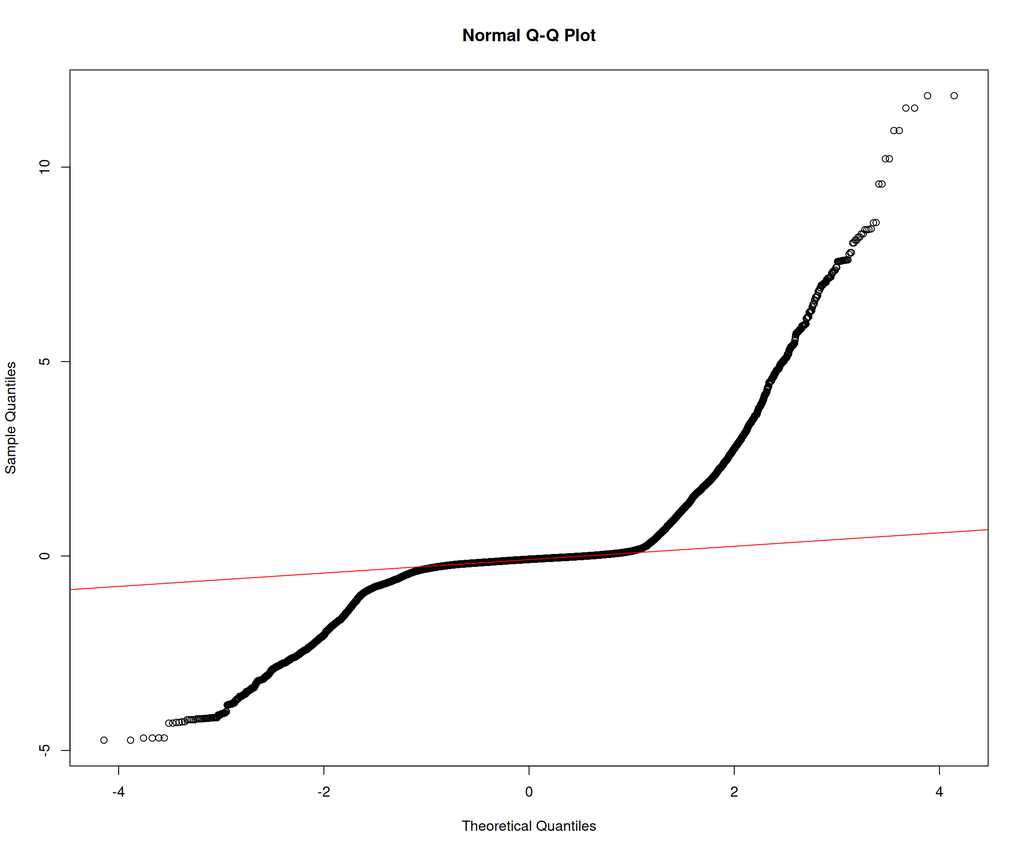

Residual Distribution Plots for Model 1

```r
# Q-Q plot of standardized residuals
qqnorm(rstandard(model1))
qqline(rstandard(model1), col = "red")
```

## 4.4 Check outliers or influential points

```r
# Check for outliers or influential points

performance::check_outliers(model1)
```

```
OK: No outliers detected.
- Based on the following method and threshold: cook (0.839).
- For variable: (Whole model)
```

## 4.5 Examine the residuals

```r
# Extract residuals
residuals <- resid(model1)

# Standardize the residuals
std_residuals <- residuals / sd(residuals)

# Calculate max and min of the standardized residuals
max_std_residual <- max(std_residuals)
min_std_residual <- min(std_residuals)

# Print the results
cat("Max standardized residual:", max_std_residual, "\n")
```

```
Max standardized residual: 11.83653
```

```r
cat("Min standardized residual:", min_std_residual, "\n")
```

```
Min standardized residual: -4.736472
```

```r
#Identify potential outliers in the dataset based on the studentized residuals of the model.
car::outlierTest(model1) # Bonferonni p-value for most extreme observations - observations with a p value lower than the threshold are consider outliers.
```

```
       rstudent unadjusted p-value Bonferroni p
13843 11.864825         2.1408e-32   6.2412e-28
27872 11.864825         2.1408e-32   6.2412e-28
10706 11.544172         9.2164e-31   2.6870e-26
25213 11.544172         9.2164e-31   2.6870e-26
11252 10.962563         6.5577e-28   1.9118e-23
25734 10.962563         6.5577e-28   1.9118e-23
10709 10.233094         1.5508e-24   4.5213e-20
25216 10.233094         1.5508e-24   4.5213e-20
2140   9.580908         1.0355e-21   3.0189e-17
17382  9.580908         1.0355e-21   3.0189e-17
```

```r
# In this case there is only one row


# to determien the number of residuals that are > 3 OR < -3
outlier_count <- sum(std_residuals > 3 | std_residuals < -3)

# orint otu the outlier count for residuals outside the limits
cat("Number of observations exceeding +/- 3 standard deviations:", outlier_count, "\n")
```

```
Number of observations exceeding +/- 3 standard deviations: 734
```

## 4.6 Check homoscedasticity (equal variance)

```r
performance::check_heteroscedasticity(model1)
```

[output not shown]

## 4.7 Check multi-colinearity

```r
# Check multicollinearity

performance::check_collinearity(model1)
```

```
# Check for Multicollinearity

Low Correlation

 Term  VIF     VIF 95% CI adj. VIF Tolerance Tolerance 95% CI
   ph 1.29 [ 1.27,  1.31]     1.14      0.77     [0.76, 0.79]

Moderate Correlation

        Term  VIF     VIF 95% CI adj. VIF Tolerance Tolerance 95% CI
 temperature 8.99 [ 8.80,  9.19]     3.00      0.11     [0.11, 0.11]

High Correlation

                         Term   VIF     VIF 95% CI adj. VIF Tolerance
             dissolved.oxygen 14.30 [13.99, 14.62]     3.78      0.07
 dissolved.oxygen:temperature 21.39 [20.91, 21.87]     4.62      0.05
 Tolerance 95% CI
     [0.07, 0.07]
     [0.05, 0.05]
```

## 4.8 Summary Diagnostic Plots

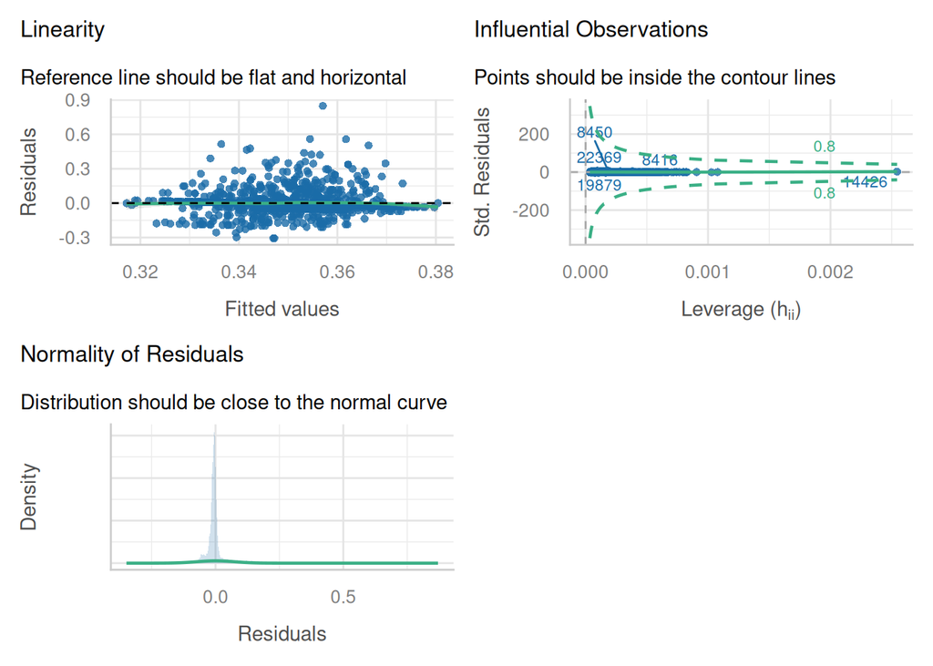

```r
#| fig.width: 12
#| fig.height: 10
#| fig-cap: "Diagnostic plots for Model 1"

# If using R 4.4.x
performance::check_model(model1,
  check = c(
    "linearity",
    "homoscedasticity",
    "outliers",
    "collinearity",
    "normality"
  )
)
```

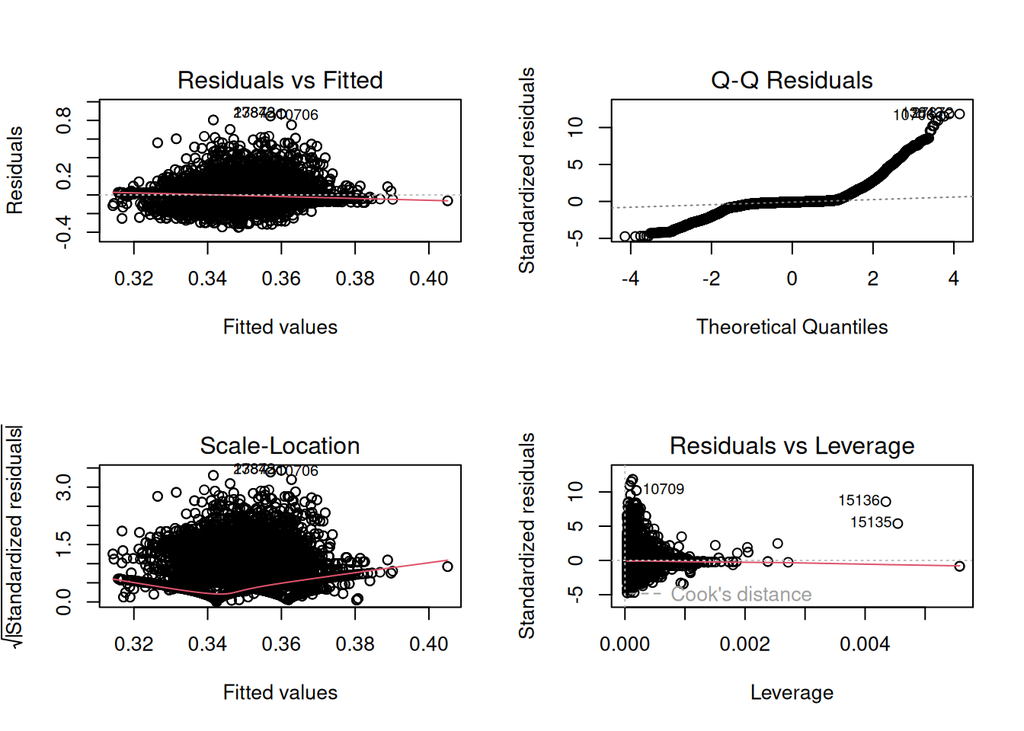

```r
# If using R 4.5.x Show all 4 diagnostic plots in one figure using R basic plots
par(mfrow = c(2, 2))   # 2x2 grid layout
plot(model1)            # Generates: Residuals vs Fitted, Normal Q-Q, Scale-Location, Cook’s distance
```

```r
par(mfrow = c(1, 1))    # Reset layout
```

## 4.9 Report

The **Residuals vs Fitted** values plot displayed a generally random scatter around the zero line, with evidence of heteroscedasticity (p < 0.001 ), deviating from the assumption of constant variance. This was also confirmed in the **Scale-Location** plot by the upward trend in fitted values. However, given the large sample size (n=29,154), our number of outliers at 734 means this does not have a sufficient effect on the model to invalidate it.

Collinearity statistics showed low intercorrelation for **ph** (VIF = 1.29), moderate for **temperature** (VIF = 8.99), and high intercorrelation for **DO** (VIF = 14.30) and **interaction effect** (VIF = 21.39). This was an initial concern as our values exceeded our threshold values of VIF > 5 and for Tolerance < 0.2., above which are indicates concerns over the presence of multicollinearity, and required further investigation. The interaction effect in our model is comprised of existing variables, thus the inclusion of this interaction effect will inherently led to high VIF values, and is termed *structural multicollinearity* i.e. multicollinearity in the model and not in the data itself. Adjusted VIF and Tolerance values from our calculations were (**ph** - VIF = 1.14, Tolerance = 0.77), (**temperature** - VIF = 3.00, Tolerance = 0.11), (**dissolved oxygen (DO)** - VIF = 3.78, Tolerance = 0.07) and **Interaction effect** - VIF = 4.62, Tolerance = 0.05) and Tolerance for each predictor), and while some Tolerance values remained low, the adjusted VIF values are below our threshold value of 5 and as such tolerable, indicating multicolinearity is not severe enough to compromise the model. [Multicollinearity in Regression Analysis: Problems, Detection, and Solutions](https://statisticsbyjim.com/regression/multicollinearity-in-regression-analysis/)

Although several assumptions were violated, namely normality and homoscedasticity, these deviations were explainable by our data structure and high n value, and do not invalidate the model.

# 5. Create comparson model using categorical variable ‘month’

```r
# create a factor from month
mlr_t1_t3_df$month <- factor(mlr_t1_t3_df$month)
# set the reference level to be jan
mlr_t1_t3_df$month <- relevel(mlr_t1_t3_df$month, ref = "Jan")

#  Build the Comparison Model (Model 2)
model2 <- lm(bod_log10 ~ dissolved.oxygen + temperature + ph + temperature:dissolved.oxygen + month, data = mlr_t1_t3_df)
```

## 5.1 Generate the Analysis of Variance Table

```r
anova(model2)
```

```
Analysis of Variance Table

Response: bod_log10
                                Df  Sum Sq Mean Sq F value    Pr(>F)
dissolved.oxygen                 1   0.100 0.09983  18.532 1.676e-05 ***
temperature                      1   1.773 1.77260 329.081 < 2.2e-16 ***
ph                               1   0.379 0.37934  70.423 < 2.2e-16 ***
month                           11   0.744 0.06763  12.556 < 2.2e-16 ***
dissolved.oxygen:temperature     1   0.214 0.21385  39.702 3.001e-10 ***
Residuals                    29138 156.952 0.00539
---
Signif. codes:  0 '***' 0.001 '**' 0.01 '*' 0.05 '.' 0.1 ' ' 1
```

## 5.2 Generate the summary statistics needed to assess model fit

```r
summary(model2)
```

```
Call:
lm(formula = bod_log10 ~ dissolved.oxygen + temperature + ph +
    temperature:dissolved.oxygen + month, data = mlr_t1_t3_df)

Residuals:
     Min       1Q   Median       3Q      Max
-0.35325 -0.01645 -0.00636  0.00263  0.86453

Coefficients:
                               Estimate Std. Error t value Pr(>|t|)
(Intercept)                   2.453e-01  7.182e-03  34.151  < 2e-16 ***
dissolved.oxygen              3.718e-04  6.137e-05   6.059 1.39e-09 ***
temperature                   4.882e-03  4.073e-04  11.985  < 2e-16 ***
ph                            7.071e-03  8.488e-04   8.330  < 2e-16 ***
monthApr                     -5.366e-03  2.311e-03  -2.322  0.02023 *
monthAug                      9.744e-04  2.850e-03   0.342  0.73242
monthDec                      2.665e-03  2.619e-03   1.017  0.30894
monthFeb                      2.979e-03  2.183e-03   1.364  0.17246
monthJul                     -1.714e-02  2.805e-03  -6.112 9.96e-10 ***
monthJun                     -3.340e-03  2.673e-03  -1.250  0.21146
monthMar                     -5.607e-04  2.296e-03  -0.244  0.80712
monthMay                     -8.751e-03  2.575e-03  -3.398  0.00068 ***
monthNov                      3.696e-03  2.268e-03   1.630  0.10319
monthOct                     -1.704e-03  2.376e-03  -0.717  0.47336
monthSep                     -1.177e-03  2.573e-03  -0.457  0.64732
dissolved.oxygen:temperature -3.372e-05  5.352e-06  -6.301 3.00e-10 ***
---
Signif. codes:  0 '***' 0.001 '**' 0.01 '*' 0.05 '.' 0.1 ' ' 1

Residual standard error: 0.07339 on 29138 degrees of freedom
Multiple R-squared:  0.02004,   Adjusted R-squared:  0.01954
F-statistic: 39.72 on 15 and 29138 DF,  p-value: < 2.2e-16
```

## 5.3 Generate Standardized Co-efficients

```r
lm.beta::lm.beta(model2)
```

```
Call:
lm(formula = bod_log10 ~ dissolved.oxygen + temperature + ph +
    temperature:dissolved.oxygen + month, data = mlr_t1_t3_df)

Standardized Coefficients::
                 (Intercept)             dissolved.oxygen
                          NA                  0.135172937
                 temperature                           ph
                 0.233173412                  0.055449060
                    monthApr                     monthAug
                -0.021212854                  0.003452893
                    monthDec                     monthFeb
                 0.007598312                  0.011915753
                    monthJul                     monthJun
                -0.062192197                 -0.013267525
                    monthMar                     monthMay
                -0.002001807                 -0.030557068
                    monthNov                     monthOct
                 0.014632560                 -0.007088369
                    monthSep dissolved.oxygen:temperature
                -0.004687496                 -0.171469679
```

## 5.4 Use Stargazer to produce a tidy output of ANOVA and Summary

```r
stargazer(model2, type="text") #Tidy output of all the required stats
```

```
========================================================
                                 Dependent variable:
                             ---------------------------
                                      bod_log10
--------------------------------------------------------
dissolved.oxygen                      0.0004***
                                      (0.0001)

temperature                           0.005***
                                      (0.0004)

ph                                    0.007***
                                       (0.001)

monthApr                              -0.005**
                                       (0.002)

monthAug                                0.001
                                       (0.003)

monthDec                                0.003
                                       (0.003)

monthFeb                                0.003
                                       (0.002)

monthJul                              -0.017***
                                       (0.003)

monthJun                               -0.003
                                       (0.003)

monthMar                               -0.001
                                       (0.002)

monthMay                              -0.009***
                                       (0.003)

monthNov                                0.004
                                       (0.002)

monthOct                               -0.002
                                       (0.002)

monthSep                               -0.001
                                       (0.003)

dissolved.oxygen:temperature         -0.00003***
                                      (0.00001)

Constant                              0.245***
                                       (0.007)

--------------------------------------------------------
Observations                           29,154
R2                                      0.020
Adjusted R2                             0.020
Residual Std. Error              0.073 (df = 29138)
F Statistic                  39.724*** (df = 15; 29138)
========================================================
Note:                        *p<0.1; **p<0.05; ***p<0.01
```

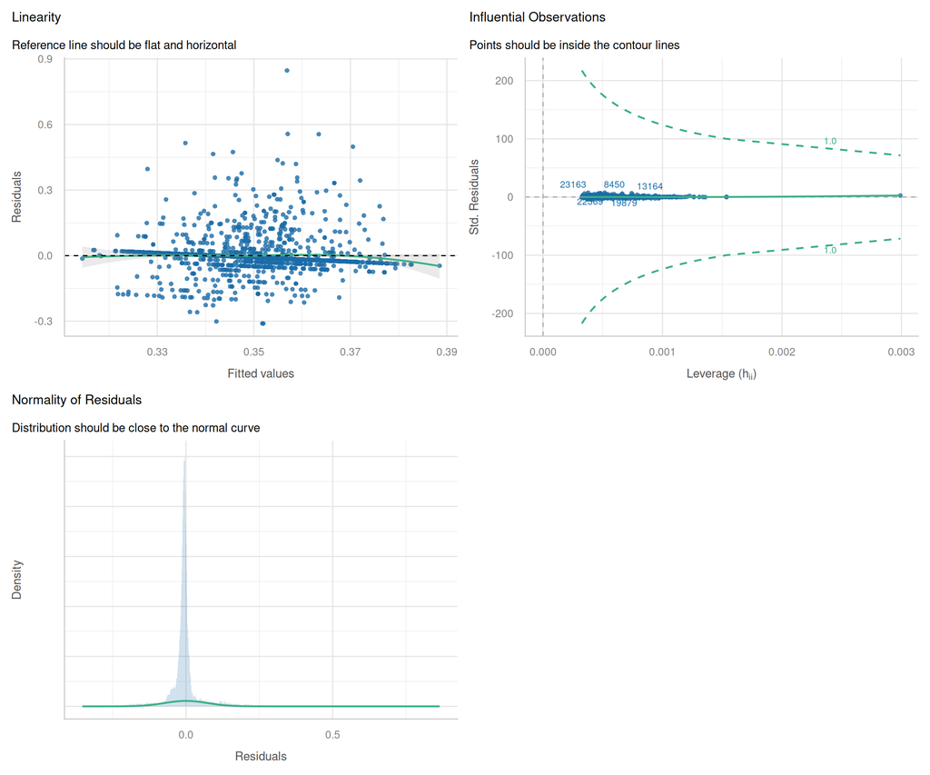

Diagnostic plots for Model 2

```r
# If using R 4.4.x
performance::check_model(model2,
  check = c(
    "linearity",
    "homoscedasticity",
    "outliers",
    "collinearity",
    "normality"
  )
)
```

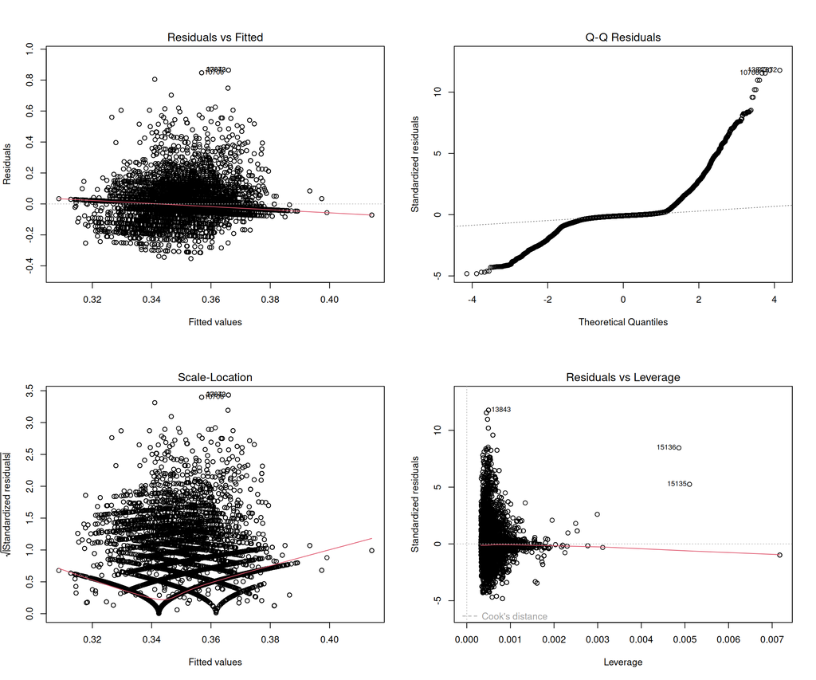

Diagnostic plots for Model 2

```r
# If using R 4.5.x Show all 4 diagnostic plots in one figure using R basic plots
par(mfrow = c(2, 2))   # 2x2 grid layout
plot(model2)            # Generates: Residuals vs Fitted, Normal Q-Q, Scale-Location, Cook’s distance
```

```r
par(mfrow = c(1, 1))    # Reset layout
```

## 5.5 Month effects report

There is evidence of support for our **H2 hypothesis** which sates that including **month** as a categorical predictor significantly improves the model, effectively explaining **BOD** monthly variations, relative to January. We note however that the increase is only ‘0.4%’ in variance explained. So while the Hypothesis is supported, and monthly variations are significant, **temperature** and **DO** remain the primary predictors on **BOD**.

The inclusion of **month** as a categorical predictor significantly improves the model fit explaining additional monthly variation in **BOD**, relative to the January baseline.

# 6 Comparison model vs Baseline model

## 6.1 Generate Analysis of Variance Table for both models

This provides the information needed to calculate the F statistic.

```r
anova(model1, model2)
```

```
Analysis of Variance Table

Model 1: bod_log10 ~ dissolved.oxygen + temperature + ph + (temperature *
    dissolved.oxygen)
Model 2: bod_log10 ~ dissolved.oxygen + temperature + ph + temperature:dissolved.oxygen +
    month
  Res.Df    RSS Df Sum of Sq      F    Pr(>F)
1  29149 157.67
2  29138 156.95 11   0.71791 12.116 < 2.2e-16 ***
---
Signif. codes:  0 '***' 0.001 '**' 0.01 '*' 0.05 '.' 0.1 ' ' 1
```

## 6.2 Comparison vs Baseline Report

The anova comparison data shows that adding **month** resulted in a statistically significant reduction in the sum of squares (F(11, 29,138) = 12.12, p <0.001)), with delta sum of squares between model 1 and model 2 across 11 additional degrees of freedom.

This indicates the the month explains a significant portion of the additional variance in BOD beyond that accounted for by **DO**, **temperature** or **ph**, and model 2 is significantly better.

The baseline Adjusted R-squared = 0.01542 and comparison model 2 Adjusted R-squared = 0.01954. Means a delta adjusted R squared value = 0.00412. This indicates and increase from 1.5% to 1.9% of variance is accounted for in **BOD** variance by including the **month** variable, which, while it is small, is an improvement in predictive power.

The small increase in adjusted R squared, suggests that while the seasonal effects are statistically significant, the drivers of BOD remain **DO**, **temperature** or **ph**, rather than seasonal variation.

## 6.3 Further investigation

- compare our predictive results against the **WQI** categorical metrics present in our original dataset. Due to time constraints this could not be carried out here here, but would be a good next steps to see how our predictive model matches with those WQI classification standards, and how they compare to each other across particular variables to see which variables are driving water quality hw most across standard water quality models.
- **DO** : We saw that excellent water quality is achieved at lower values of **DO** while poor water quality is achieved at higher values. This pattern is contrary to the expected ecological relationship between DO and water quality, where higher oxygen typically indicates better conditions. In our model this may be explainable by the use **DO** in the interaction effect, namely how it changes the impact of temperature on water quality, rather than being a simple linear predictor of quality. The relationship and interaction effects on water quality and other predictors would be a good area to investigate further to try clarify.
- Assign categorical values on our outcome values, ir range of values i.e. by creating categories off specific category ranges we can create an ‘excellent’, ‘good’, ‘poor’, ‘very poor’ categorization of water quality and apply and compare them to other classifications, and make them more easily interpretable.
- Increase predictive power in the model i.e. look for other data that has a great prdedictive power on water quality i.e. only 1.5% BOD variance was accounted for in our model. Other factors could be local farming practices, nutrients (phosphates/nitrogen) present in th water, amount of rain. and many others…